# Grupos de Discusión

Seminario de Investigación

Álvaro Canalejo-Molero

Instituto de Políticas y Bienes Públicos (IPP) - CSIC

## Sobre mí

Postdoc en el [IPP-CSIC](https://www.ipp.csic.es), proyecto [CONSENT](https://cordis.europa.eu/project/id/101170551)

- Antes: postdoc en Lucerna; estancias en la UAB y la LSE
- Doctorado en el [EUI](https://www.eui.eu) (2023)

**Investigo** actitudes y comportamiento político

- Resultados electorales y consentimiento de los perdedores
- Cambio tecnológico digital y conflicto político
- Identidades múltiples y representación

## Qué son los grupos de discusión

- Conversación guiada en grupo sobre un tema de investigación
- Lo central es la **interacción**
- Objetivo: hacer emerger **significados compartidos**

|  | Entrevista | Grupo |
| --- | --- | --- |
| Se habla ante | El entrevistador | Moderador y pares |
| Obtenemos | Relatos individuales | Discursos comunes |

## CONSENT

[ERC Consolidator Grant](https://cordis.europa.eu/project/id/101170551) (2025-2030)

- Ignacio Jurado (IP), Josep Serrano Serrat y yo

**RQs:**

- ¿Por qué los perdedores aceptan los resultados electorales?
- ¿Qué rompe ese consentimiento?

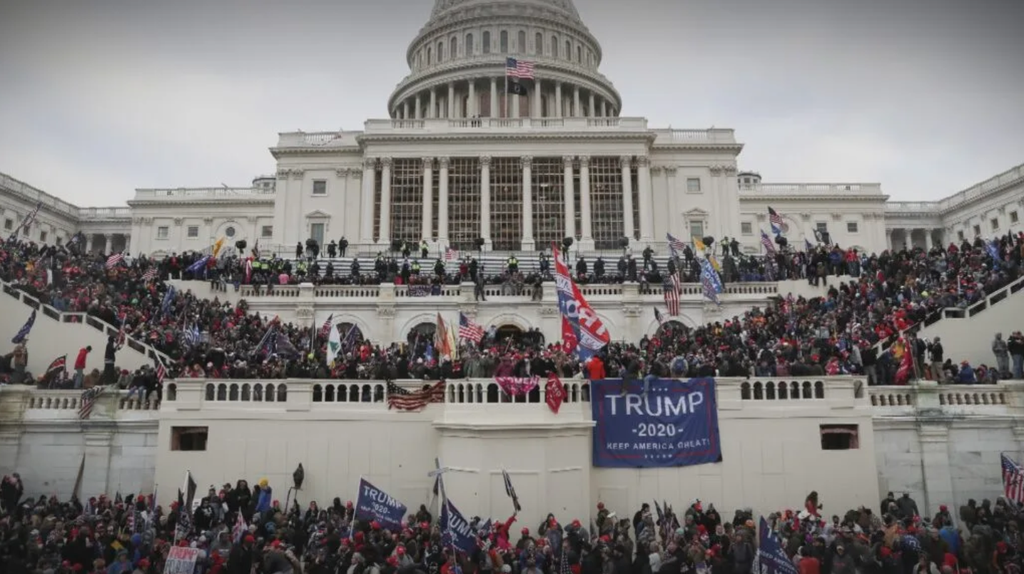

## De dónde partimos

- Muchas teorías, **poco testadas**
- Pensadas sobre todo **para las élites** (ej., aceptan porque esperan ganar la próxima vez; porque el coste de contestar los resultados es mayor que las posibles ganancias, etc.)

¿Cuáles de estas teorías explican mejor el comportamiento ciudadano?

¿Existen **otras explicaciones**?

## ¿Por qué grupos de discusión?

- Encuestas y experimentos: inferencias descriptivas y causales
- Grupos de discusión:
  - **Antes**: explorar ideas y preparar diseños cuantitativos
  - **Después**: interpretar resultados
- Objetivo inicial mixto:
  - Generación de teoría (*theory-building*)
  - Validación de teorías (*theory-testing*)

## Selección de casos

| País | Por qué |
| --- | --- |
| EE.UU. y Brasil | Retroceso democrático |
| España | Estabilidad con polarización |
| Hungría | Justo tras las elecciones |
| Corea del Sur | Ley marcial |

## Composición

| País | Grupos |
| --- | --- |
| Hungría (piloto) | 1 perdedores, 1 ganadores, 1 mixto |
| EE.UU. | 2 demócratas, 2 republicanos |
| Brasil | 2 Lula, 2 Bolsonaro |
| España | 1 izquierda, 1 PP, 1 Vox, 1 independentistas |
| Corea del Sur | 1 izquierda, 1 derecha, 1 mixto |

## El guion

- Parte 1 (inductiva): **experiencias** de elecciones y derrotas
- Parte 2 (deductiva): *juego* con explicaciones teóricas

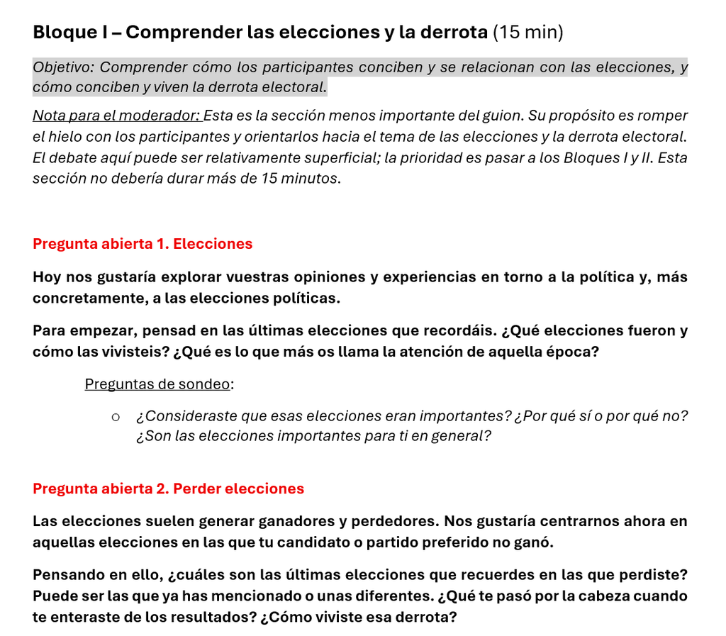

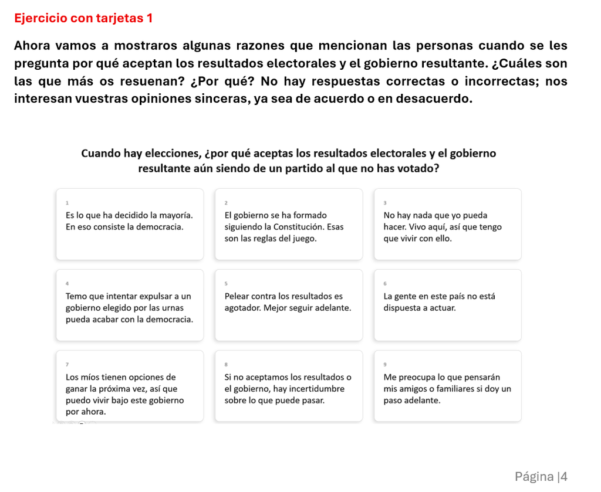

## Análisis con enfoque abductivo

1. Categorías **predefinidas**
2. Categorías **emergentes**
3. Ida y vuelta entre datos y teoría

**Libro de códigos**

- En construcción
- **Unidad**: cada idea con sentido propio y relevancia política

El **análisis** se realiza con software específico ([MAXQDA](https://www.maxqda.com))

[figure not shown]

## Extra: preguntas abiertas

- Entre el análisis cualitativo y cuantitativo
- Mismo enfoque: codificar texto de manera abductiva
- Complementan resultados con explicaciones detalladas

[figure not shown]

## Gracias!

alvaro.canalejo@cchs.csic.es

## Boas, Hidalgo y Melo (2019)

[*Norms versus Action*](https://people.bu.edu/tboas/norms_vs_action.pdf), AJPS

- **Puzzle**: castigan la corrupción en experimentos de viñeta, pero no en las urnas
- **Grupos de discusión** tras las elecciones en 3 municipios
  - La corrupción **no surge**: hablan de empleo, sequía y sanidad
  - Lealtad a **dinastías locales** como si fueran partidos
- Interpretan un resultado nulo y sugieren mecanismos que luego **testan con datos**